# White Wine Quality EDA by Prithwish Ganguly

alcohol and residual.sugar have to be kept at a delicate balance to maintina density of the wine.

```
##
## Call:
## lm(formula = density ~ alcohol + residual.sugar, data = df)
##
## Residuals:
##        Min         1Q     Median         3Q        Max
## -0.0020196 -0.0005852 -0.0001403  0.0004674  0.0249805
##
## Coefficients:
##                  Estimate Std. Error t value Pr(>|t|)
## (Intercept)     1.005e+00  1.349e-04  7446.7   <2e-16 ***
## alcohol        -1.226e-03  1.189e-05  -103.2   <2e-16 ***
## residual.sugar  3.607e-04  2.884e-06   125.1   <2e-16 ***
## ---
## Signif. codes:  0 '***' 0.001 '**' 0.01 '*' 0.05 '.' 0.1 ' ' 1
##
## Residual standard error: 0.0009137 on 4895 degrees of freedom
## Multiple R-squared:  0.9067, Adjusted R-squared:  0.9067
## F-statistic: 2.379e+04 on 2 and 4895 DF,  p-value: < 2.2e-16
```

Going by the R-squared value, alcohol and residual.sugar together account for 90.67% of the density value which works alongside our predictions.

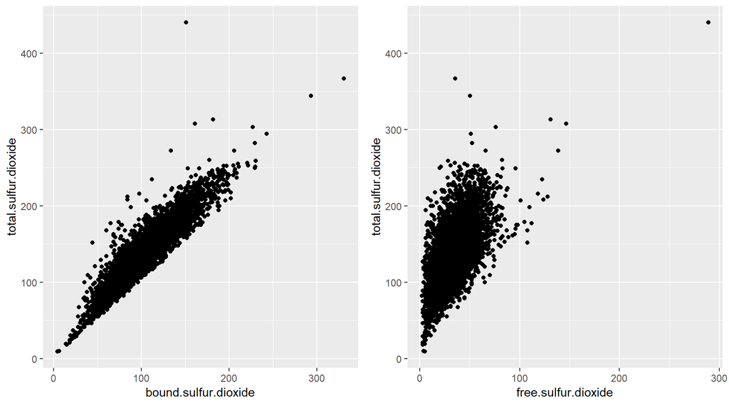

Let us remove the outliers

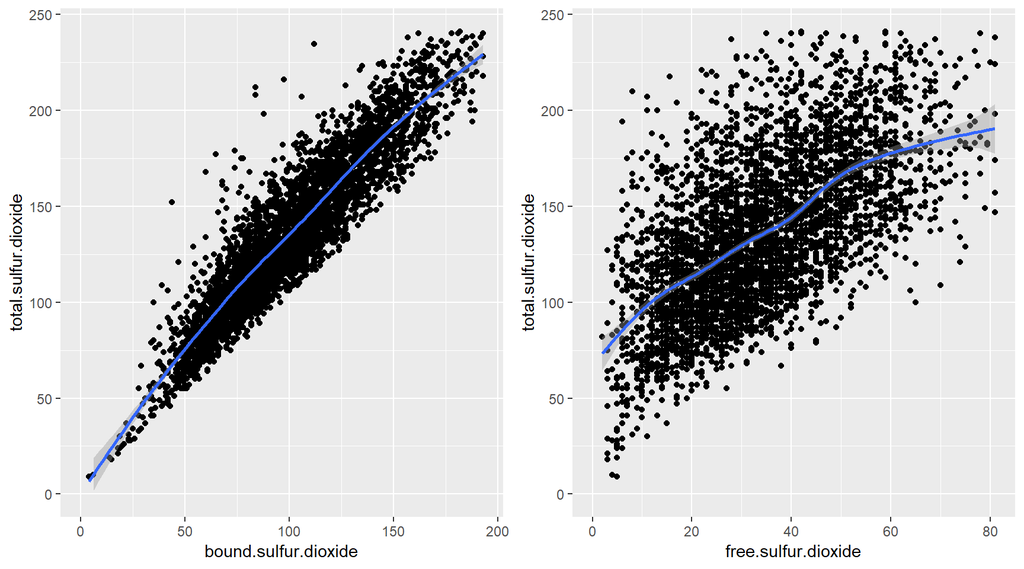

Linear trends of total.sulfur.dioxide is inherent since total.sulfur.dioxide is the sum of bound.sulfur.dioxide and free.sulfur.dioxide

```
##
## Call:
## lm(formula = total.sulfur.dioxide ~ free.sulfur.dioxide, data = df)
##
## Residuals:
##     Min      1Q  Median      3Q     Max
## -98.163 -24.891  -3.273  21.407 227.844
##
## Coefficients:
##                     Estimate Std. Error t value Pr(>|t|)
## (Intercept)         84.05553    1.10304   76.20   <2e-16 ***
## free.sulfur.dioxide  1.53804    0.02815   54.65   <2e-16 ***
## ---
## Signif. codes:  0 '***' 0.001 '**' 0.01 '*' 0.05 '.' 0.1 ' ' 1
##
## Residual standard error: 33.5 on 4896 degrees of freedom
## Multiple R-squared:  0.3788, Adjusted R-squared:  0.3787
## F-statistic:  2986 on 1 and 4896 DF,  p-value: < 2.2e-16
```

```
##
## Call:
## lm(formula = total.sulfur.dioxide ~ bound.sulfur.dioxide, data = df)
##
## Residuals:
##     Min      1Q  Median      3Q     Max
## -40.273 -11.269  -1.528   9.700 247.503
##
## Coefficients:
##                       Estimate Std. Error t value Pr(>|t|)
## (Intercept)          22.005650   0.734316   29.97   <2e-16 ***
## bound.sulfur.dioxide  1.129084   0.006753  167.20   <2e-16 ***
## ---
## Signif. codes:  0 '***' 0.001 '**' 0.01 '*' 0.05 '.' 0.1 ' ' 1
##
## Residual standard error: 16.41 on 4896 degrees of freedom
## Multiple R-squared:  0.851,  Adjusted R-squared:  0.8509
## F-statistic: 2.796e+04 on 1 and 4896 DF,  p-value: < 2.2e-16
```

So going by the R-squared values, bound.sulfur.dioxide is the higher in proportion generally in any wine.

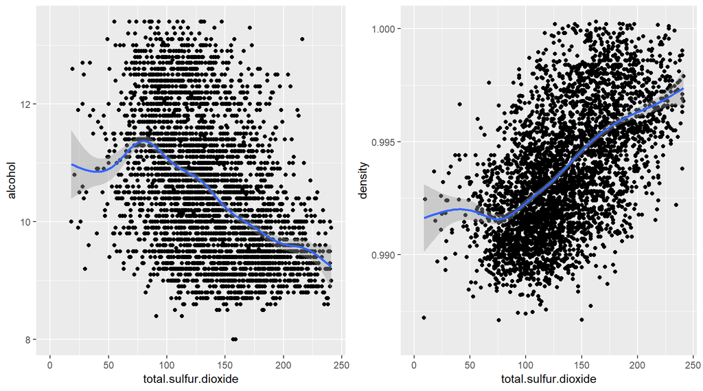

Maybe total.sulfur.dioxide and alcohol have an intertwinned relationship with density too?

```
##
## Call:
## lm(formula = density ~ alcohol + residual.sugar + free.sulfur.dioxide +
##     bound.sulfur.dioxide, data = df)
##
## Residuals:
##        Min         1Q     Median         3Q        Max
## -0.0020775 -0.0005564 -0.0001124  0.0004080  0.0247499
##
## Coefficients:
##                        Estimate Std. Error  t value Pr(>|t|)
## (Intercept)           1.003e+00  1.536e-04 6530.419  < 2e-16 ***
## alcohol              -1.151e-03  1.202e-05  -95.798  < 2e-16 ***
## residual.sugar        3.532e-04  2.850e-06  123.937  < 2e-16 ***
## free.sulfur.dioxide  -5.406e-06  7.821e-07   -6.912 5.39e-12 ***
## bound.sulfur.dioxide  8.942e-06  4.079e-07   21.925  < 2e-16 ***
## ---
## Signif. codes:  0 '***' 0.001 '**' 0.01 '*' 0.05 '.' 0.1 ' ' 1
##
## Residual standard error: 0.0008708 on 4893 degrees of freedom
## Multiple R-squared:  0.9153, Adjusted R-squared:  0.9152
## F-statistic: 1.322e+04 on 4 and 4893 DF,  p-value: < 2.2e-16
```

Well that proves it! Though a low increase in R-squared free.sulfur.dioxide and bound.sulfur.dioxide do contribute to density.

# Bivariate Analysis

### Talk about some of the relationships you observed in this part of the investigation. How did the feature(s) of interest vary with other features in the dataset?

I focussed on the variables with meaningful correlations. quality seems to be loosely related with alcohol and density.

For quality from 3 to 5, as alcohol reduces quality increases. But, for quality from 6-9, as alcohol increases quality increases.

For quality from 3 to 5, as density increased quality increases. But, for quality from 6-9, as density decreases quality increases.

The linear model for these 3 variables was not very relevant with its low R-squared value.

### Did you observe any interesting relationships between the other features (not the main feature(s) of interest)?

There is a relationship between alcohol, residual.sugar, density. As alcohol increases, density decreases. On the other hand as residual.sugar increases, density increases. I think a certain relationship between alcohol and residual.sugar is required to maintain a certain level of density. free.sulfur.dioixide and total.sulfur.dioxide are also related to related to density but at a much lower extent.

### What was the strongest relationship you found?

The strongest relationship I found was the relationship between density & residual.sugar(correlation = 0.839) and density & alcohol(correlation = -0.78).

# Multivariate Plots Section

I want to split residual.sugar into 2 groups due to its bimodal nature. I will split it by it’s median

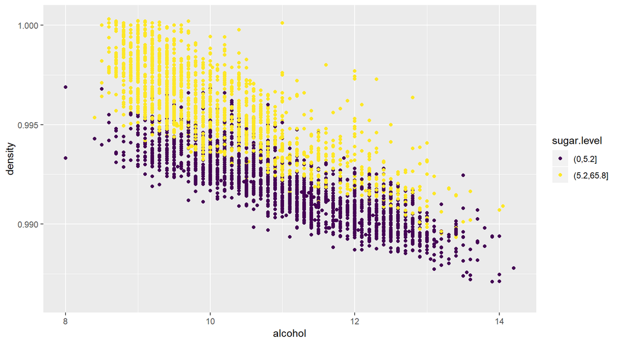

Here we observe a noticeable interpretation of our Bivariate analysis. As alcohol increases, density and sugar level decreases. As alcohol decreases, density and sugar level increases.

But, does this have an effect on quality?

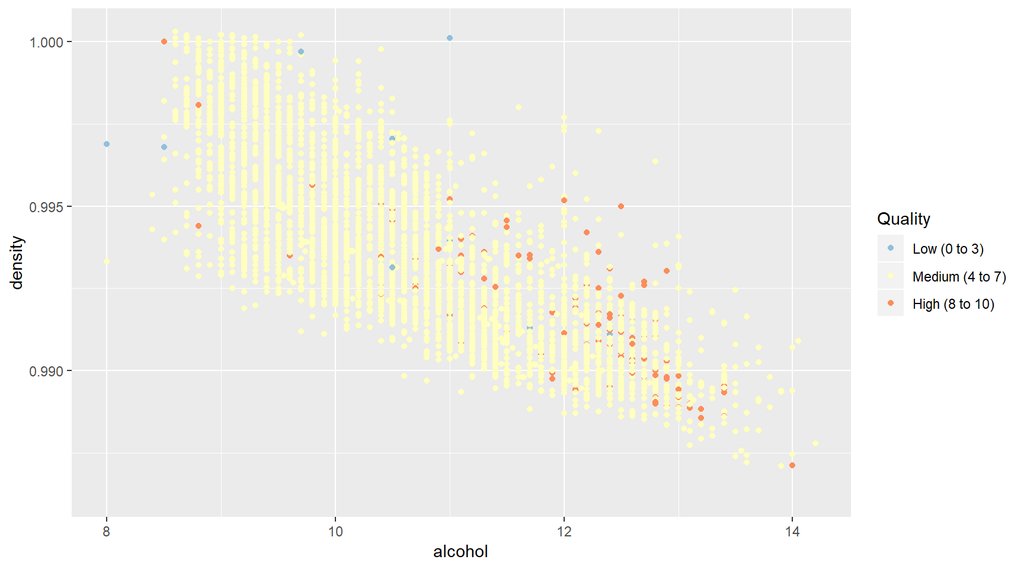

Since majority of our dataset is normal wines, this plot doesn’t give us much information. Maybe I should divide my alcohol variable into groups?

```
##    Min. 1st Qu.  Median    Mean 3rd Qu.    Max.
##    8.00    9.50   10.40   10.51   11.40   14.20
```

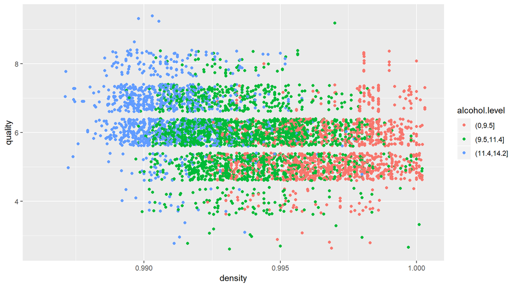

```
##    Min. 1st Qu.  Median    Mean 3rd Qu.    Max.
##  0.9871  0.9917  0.9937  0.9940  0.9961  1.0390
```

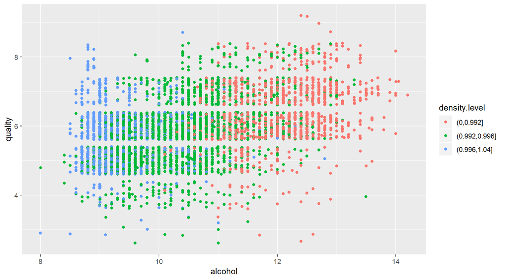

Hmm, so we obviously see the relationship between alcohol and density but visually the relationship with quality doesn’t seem obvious.

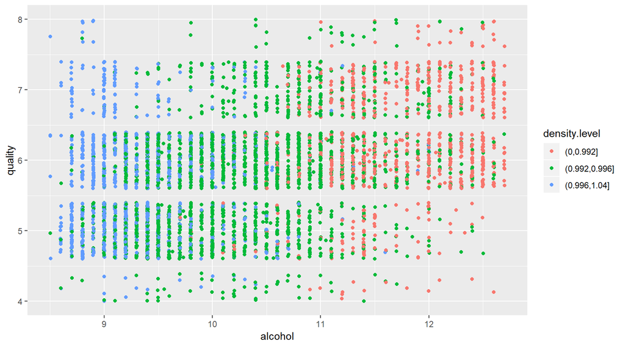

By zooming in we do notice that as the quality increases the number of low density high alcohol wines increase. This could be something.

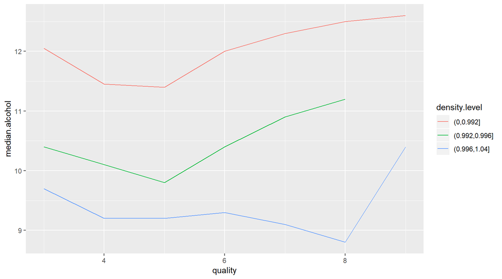

Here we clearly see for the same quality as density increases, alcohol decreases!

Let us try to create a linear model including all the values:

```
##
## Calls:
## m1: lm(formula = quality ~ alcohol, data = df)
## m2: lm(formula = quality ~ alcohol + density, data = df)
## m3: lm(formula = quality ~ alcohol + density + fixed.acidity, data = df)
## m4: lm(formula = quality ~ alcohol + density + fixed.acidity + volatile.acidity,
##     data = df)
## m5: lm(formula = quality ~ alcohol + density + fixed.acidity + volatile.acidity +
##     citric.acid, data = df)
## m6: lm(formula = quality ~ alcohol + density + fixed.acidity + volatile.acidity +
##     citric.acid + I(log10(residual.sugar)), data = df)
## m7: lm(formula = quality ~ alcohol + density + fixed.acidity + volatile.acidity +
##     citric.acid + I(log10(residual.sugar)) + chlorides, data = df)
## m8: lm(formula = quality ~ alcohol + density + fixed.acidity + volatile.acidity +
##     citric.acid + I(log10(residual.sugar)) + chlorides + free.sulfur.dioxide +
##     bound.sulfur.dioxide, data = df)
## m9: lm(formula = quality ~ alcohol + density + fixed.acidity + volatile.acidity +
##     citric.acid + I(log10(residual.sugar)) + chlorides + free.sulfur.dioxide +
##     bound.sulfur.dioxide + pH, data = df)
## m10: lm(formula = quality ~ alcohol + density + fixed.acidity + volatile.acidity +
##     citric.acid + I(log10(residual.sugar)) + chlorides + free.sulfur.dioxide +
##     bound.sulfur.dioxide + pH + sulphates, data = df)
##
## ========================================================================================================================================================================
##                                  m1            m2            m3            m4            m5            m6            m7            m8            m9           m10
## ------------------------------------------------------------------------------------------------------------------------------------------------------------------------
##   (Intercept)                   2.582***    -22.492***    -32.669***    -48.571***    -48.568***     24.044*       23.650*       20.522*       37.700***     47.757***
##                                (0.098)       (6.165)       (6.360)       (6.187)       (6.215)      (10.254)      (10.255)      (10.372)      (11.294)      (11.437)
##   alcohol                       0.313***      0.360***      0.373***      0.415***      0.415***      0.337***      0.331***      0.336***      0.310***      0.296***
##                                (0.009)       (0.015)       (0.015)       (0.014)       (0.015)       (0.017)       (0.017)       (0.017)       (0.019)       (0.019)
##   density                                    24.728***     35.427***     51.673***     51.670***    -21.112*      -20.603*      -17.623       -36.049**     -46.226***
##                                              (6.079)       (6.300)       (6.133)       (6.161)      (10.238)      (10.240)      (10.365)      (11.422)      (11.567)
##   fixed.acidity                                            -0.087***     -0.100***     -0.101***     -0.062***     -0.064***     -0.055***     -0.020        -0.014
##                                                            (0.014)       (0.014)       (0.014)       (0.015)       (0.015)       (0.015)       (0.017)       (0.017)
##   volatile.acidity                                                       -2.115***     -2.114***     -2.139***     -2.113***     -2.015***     -1.981***     -1.953***
##                                                                          (0.110)       (0.111)       (0.110)       (0.111)       (0.114)       (0.114)       (0.114)
##   citric.acid                                                                           0.001         0.035         0.056         0.024         0.057         0.037
##                                                                                        (0.096)       (0.095)       (0.096)       (0.096)       (0.096)       (0.096)
##   I(log10(residual.sugar))                                                                            0.442***      0.434***      0.391***      0.484***      0.535***
##                                                                                                      (0.050)       (0.050)       (0.051)       (0.056)       (0.057)
##   chlorides                                                                                                        -0.960        -1.029        -0.831        -0.818
```

[output cut: 21 more lines]

```
##
##    3    4    5    6    7    8    9
##   20  163 1457 2198  880  175    5
```

So the highest R-squared value we get is 0.278, so with this linear model we cannot obtain a very accurate value for quality from the given features.

# Multivariate Analysis

### Talk about some of the relationships you observed in this part of the investigation. Were there features that strengthened each other in terms of looking at your feature(s) of interest?

Here I added a third variable as color and was able to obtain a better idea about the relationship between:

- residual.sugar, alcohol and density
- quality, density and alcohol.

### Were there any interesting or surprising interactions between features?

I found the interaction between quality, density and alcohol to be very interesting. Particularly the balance they need to maintain in the white wine.

### OPTIONAL: Did you create any models with your dataset? Discuss the strengths and limitations of your model.

I tried creating a linear model to predit the quality but the results I obtained show that a linear model is probably not the best way to go to fit this model, or we are missing vital features from our dataset.

# Final Plots and Summary

### Plot One

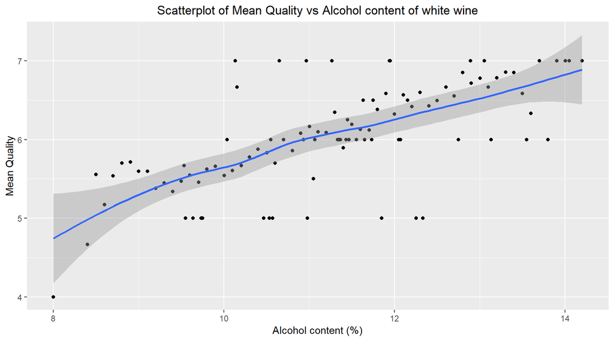

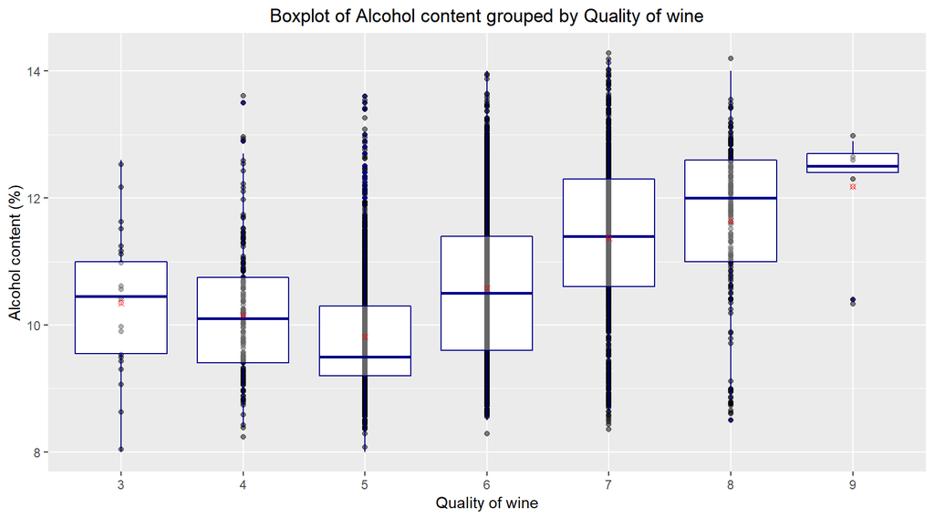

### Description One

This is one of the main features I explored in relation with quality as an outcome. Alcohol has the highest correlation with quality and its relationship can easily be viewed here by the clear linear relationship between mean quality and alcohol content that can be observed in the scatterplot. There is also a change in trends between alcohol and quality as observed by the boxplot. There seems to be a threshold of alcohol(as noticed by the dip in 5 quality) after which it needs to increases in relation with other ingredients to get a better quality of wine.

### Plot Two

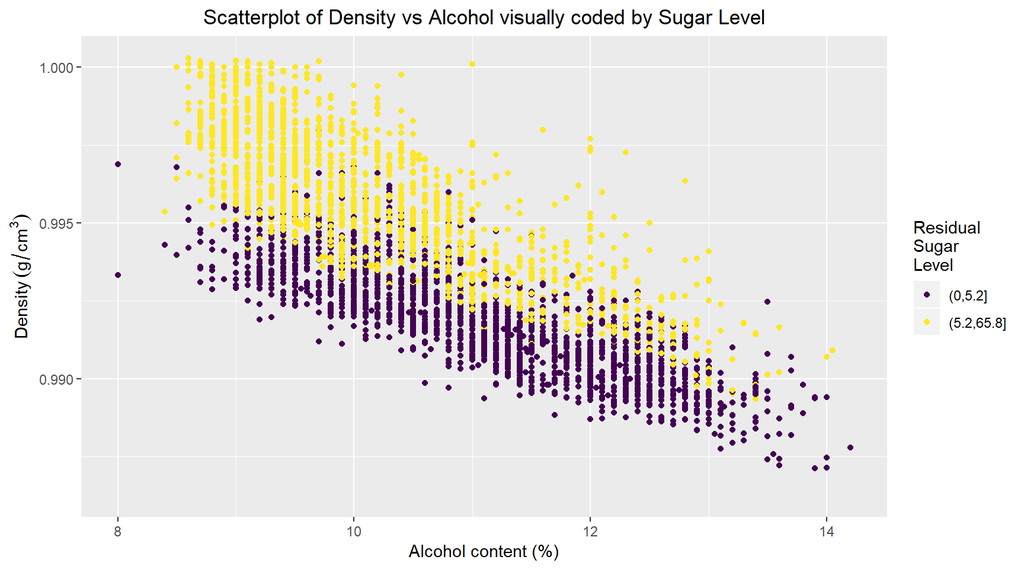

### Description Two

This plot perfectly shows the relationship between residual.sugar, alcohol and density. I has split the residual.sugar into two buckets because of it’s bimodal nature. I split the buckets by the median of residual.sugar.

As alcohol increases, density and sugar level decreases. As alcohol decreases, density and sugar level increases. This could be explained by the fact that, during the manufacturing of wine, fermentation converts the sugars to alcohol. This explains why better quality wine has had better fermentation and has allowed more of the sugars to convert to more alcohol.

### Plot Three

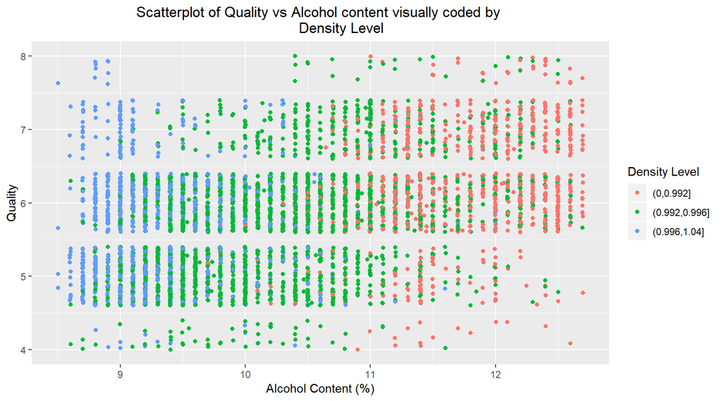

### Description Three

This plot is heavily connects to the previous plots. We can see by the number of the points on each level of quality that as quality increases, the number of low density high alcohol content points increase.

We can see a clear evidance of this as we move up from rating 5 with more blue dots and less red dots up to 7 with much more red dots and less blue. Note that blue dots always relate with low alcohol and high density wines while red dots relate with high alcohol and low density wines.

# Reflection

One of my biggest struggles was settling on which features to focus on. I think even with the report I created, I still missed out on a lot of possible avenues that I could have explored. Given more time I would have liked to delve deeper into creating a better model for predicting quality of white wine but I feel I would need more domain knowledge of the making of white wines than I currently have.

Nonetheless, I had a lot of success in using different aspects of R and its vast EDA capabilities especially in it’s visualizations. I found considerable success in showing connections between density, alcohol content and residual.sugars.

In the future, I would probably like to spend more time even exploring deadends and gathering side data as well, like cost of the wines and their age.